# Практика · Калібрування і вибір порога> Лекція: lecture.html · Домашнє завдання: homework.html · Тест: quiz.htmlДошка оголошень про вживані телефони. Дешевий фільтр відібрав підозрілі оголошення йскла

## 3 · `predict()` — це вже поріг 0.5Найкоротша клітинка зошита й найважливіша думка теми. Порівняємо готові вироки моделіз тим, що вийде, якщо взяти її ймовірності й самому порівняти їх із 0.5.

```python
from sklearn.linear_model import LogisticRegression
from sklearn.pipeline import make_pipeline
from sklearn.preprocessing import StandardScaler

logreg = make_pipeline(StandardScaler(), LogisticRegression(max_iter=1000))
logreg.fit(X_train, y_train)

proba_test = logreg.predict_proba(X_test)[:, 1]   # ймовірність класу «шахрай»
label_test = logreg.predict(X_test)               # готові вироки моделі

# те саме правило, тільки написане руками
manual_labels = (proba_test >= 0.5).astype(int)

assert np.array_equal(label_test, manual_labels), "predict() виявився чимось іншим!"
print("✅ predict() збігається з (predict_proba >= 0.5) на всіх", len(y_test), "оголошеннях")
print("розбіжностей:", int((label_test != manual_labels).sum()))
```

```
✅ predict() збігається з (predict_proba >= 0.5) на всіх 2100 оголошеннях
розбіжностей: 0
```

## 4 · Скільки коштує помилкаЗаблокувати чесне оголошення (FP) коштує майданчику ~200 грн: втрачена комісія йробота підтримки. Пропустити шахрайське (FN) коштує ~1800 грн: повернення грошейпокупцеві та розгляд скарги.Порахуємо сумарні втрати для кожного порогу від 0.01 до 0.99 і знайдемо найдешевший.

```python
COST_FALSE_ALARM = 200     # ціна хибної тривоги, грн
COST_MISS = 1800           # ціна пропуску, грн

def losses_at(scores, y_true, threshold):
    """Сумарні втрати в гривнях, якщо блокувати все, що не нижче порога."""
    predicted = (scores >= threshold).astype(int)
    false_alarms = int(((predicted == 1) & (y_true == 0)).sum())
    misses = int(((predicted == 0) & (y_true == 1)).sum())
    return COST_FALSE_ALARM * false_alarms + COST_MISS * misses

thresholds = np.round(np.arange(0.01, 1.00, 0.01), 2)
loss_curve = np.array([losses_at(proba_test, y_test, t) for t in thresholds])

best_index = int(loss_curve.argmin())
best_threshold = thresholds[best_index]
formula_threshold = COST_FALSE_ALARM / (COST_FALSE_ALARM + COST_MISS)

print("поріг 0.50 (за замовчуванням):", losses_at(proba_test, y_test, 0.5), "грн")
print("найкращий поріг на даних:     ", best_threshold, "→", loss_curve[best_index], "грн")
print("поріг за формулою:            ", formula_threshold, "→",
      losses_at(proba_test, y_test, formula_threshold), "грн")
print("формула дорожча за фактичний мінімум на",
      round(100 * (losses_at(proba_test, y_test, formula_threshold) - loss_curve[best_index])
            / loss_curve[best_index], 2), "%")
```

```
поріг 0.50 (за замовчуванням): 610000 грн
найкращий поріг на даних:      0.09 → 237200 грн
поріг за формулою:             0.1 → 240800 грн
формула дорожча за фактичний мінімум на 1.52 %
```

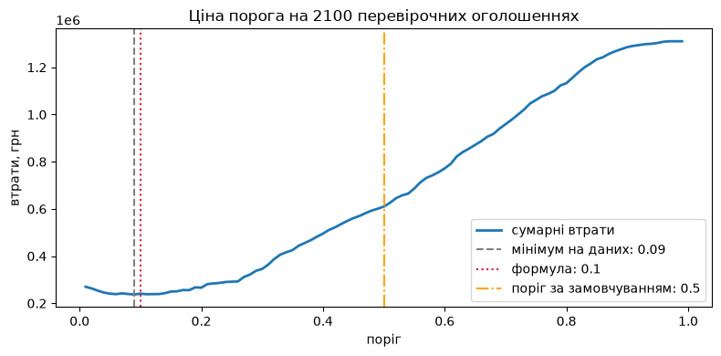

```
економія від правильного порога: 372800 грн
```

```python
import matplotlib.pyplot as plt

plt.figure(figsize=(8, 4))
plt.plot(thresholds, loss_curve, linewidth=2, label="сумарні втрати")
plt.axvline(best_threshold, linestyle="--", color="gray",
            label=f"мінімум на даних: {best_threshold}")
plt.axvline(formula_threshold, linestyle=":", color="crimson",
            label=f"формула: {formula_threshold}")
plt.axvline(0.5, linestyle="-.", color="orange", label="поріг за замовчуванням: 0.5")
plt.xlabel("поріг")
plt.ylabel("втрати, грн")
plt.title("Ціна порога на 2100 перевірочних оголошеннях")
plt.legend()
plt.tight_layout()
plt.show()

print("економія від правильного порога:",
      losses_at(proba_test, y_test, 0.5) - loss_curve[best_index], "грн")
```

## 5 · Три інші вимоги — три інші порогиЦіни помилок відомі не завжди. Подивимось, який поріг дають три поширені вимоги:задана повнота, квота на кількість хибних тривог і максимум F1.

```python
from sklearn.metrics import precision_recall_fscore_support

def report_at(threshold):
    """Повнота, точність, F1 і кількість хибних тривог для одного порога."""
    predicted = (proba_test >= threshold).astype(int)
    precision, recall, f1, _ = precision_recall_fscore_support(
        y_test, predicted, average="binary", zero_division=0)
    false_alarms = int(((predicted == 1) & (y_test == 0)).sum())
    return precision, recall, f1, false_alarms

# рахуємо звіт один раз для кожного порога, далі просто дивимось у нього
report = {t: report_at(t) for t in thresholds}

# 1) найвищий поріг, за якого повнота ще не нижча за 0.90
recall_rule = max(t for t in thresholds if report[t][1] >= 0.90)
# 2) найнижчий поріг, за якого хибних тривог не більше за 150
quota_rule = min(t for t in thresholds if report[t][3] <= 150)
# 3) поріг із найбільшою F1
f1_rule = thresholds[int(np.argmax([report[t][2] for t in thresholds]))]

rules = pd.DataFrame([
    ("нічого не обирали", 0.5),
    ("повнота >= 0.90", recall_rule),
    ("не більше 150 тривог", quota_rule),
    ("максимум F1", f1_rule),
    ("мінімум втрат", best_threshold),
], columns=["вимога", "поріг"])
rules["precision"] = [round(report_at(t)[0], 3) for t in rules["поріг"]]
rules["recall"] = [round(report_at(t)[1], 3) for t in rules["поріг"]]
rules["F1"] = [round(report_at(t)[2], 3) for t in rules["поріг"]]
rules["хибних тривог"] = [report_at(t)[3] for t in rules["поріг"]]
rules["втрати, грн"] = [losses_at(proba_test, y_test, t) for t in rules["поріг"]]
print(rules.to_string(index=False))
```

```
              вимога  поріг  precision  recall    F1  хибних тривог  втрати, грн
   нічого не обирали   0.50      0.686   0.563 0.618            188       610000
     повнота >= 0.90   0.20      0.476   0.908 0.625            727       266000
не більше 150 тривог   0.54      0.718   0.515 0.600            147       664800
         максимум F1   0.30      0.544   0.812 0.652            495       345600
       мінімум втрат   0.09      0.413   0.973 0.580           1006       237200
```

```python
def reliability_by_hand(scores, y_true, n_bins=10):
    """Наш власний розрахунок діаграми надійності: середня оцінка й факт у кожному кошику."""
    bin_index = np.clip((scores * n_bins).astype(int), 0, n_bins - 1)
    mean_predicted, actual_share, sizes = [], [], []
    for b in range(n_bins):
        inside = bin_index == b
        if inside.sum() == 0:          # порожній кошик просто не дає точки
            continue
        mean_predicted.append(scores[inside].mean())
        actual_share.append(y_true[inside].mean())
        sizes.append(int(inside.sum()))
    return np.array(mean_predicted), np.array(actual_share), np.array(sizes)

predicted_by_bin, actual_by_bin, bin_sizes = reliability_by_hand(proba_test, y_test)

table = pd.DataFrame({
    "оголошень": bin_sizes,
    "середня оцінка": np.round(predicted_by_bin, 3),
    "фактична частка": np.round(actual_by_bin, 3),
    "розрив": np.round(np.abs(predicted_by_bin - actual_by_bin), 3),
})
print(table.to_string(index=False))
```

```
 оголошень  середня оцінка  фактична частка  розрив
       418           0.047            0.060   0.012
       294           0.152            0.143   0.009
       302           0.249            0.232   0.017
       271           0.350            0.376   0.027
       217           0.447            0.364   0.083
       192           0.549            0.521   0.028
       164           0.646            0.671   0.025
       130           0.746            0.769   0.023
        96           0.840            0.896   0.055
        16           0.932            0.875   0.057
```

Те саме вміє `sklearn.calibration.calibration_curve`. Звіримо до останнього знака —усередині бібліотеки немає магії, там рівно той самий цикл по кошиках.

```python
from sklearn.calibration import calibration_curve

library_actual, library_predicted = calibration_curve(y_test, proba_test, n_bins=10)

assert np.allclose(library_predicted, predicted_by_bin), "середні оцінки розійшлися!"
assert np.allclose(library_actual, actual_by_bin), "фактичні частки розійшлися!"
print("✅ наш розрахунок збігається з calibration_curve у всіх",
      len(predicted_by_bin), "кошиках")
```

```
✅ наш розрахунок збігається з calibration_curve у всіх 10 кошиках
```

## 7 · Brier score і ECE**Brier** — середній квадрат різниці між оцінкою та фактом (0 або 1). Міряє одразудві речі: чи вміє модель розрізняти й чи чесні її числа.**ECE** — середній розрив «обіцяне мінус фактичне», зважений за розміром кошика.Міряє тільки калібрування.Обидва напишемо самі й звіримо Brier із бібліотечним.

```python
from sklearn.metrics import brier_score_loss, roc_auc_score

def brier_by_hand(scores, y_true):
    """Середній квадрат промаху: те саме, що середньоквадратична помилка для ймовірностей."""
    return float(np.mean((scores - y_true) ** 2))

def expected_calibration_error(scores, y_true, n_bins=10):
    """Середній розрив між обіцянкою й фактом, зважений за кількістю оголошень у кошику."""
    predicted, actual, sizes = reliability_by_hand(scores, y_true, n_bins)
    return float(np.sum(sizes / len(y_true) * np.abs(predicted - actual)))

assert np.isclose(brier_by_hand(proba_test, y_test),
                  brier_score_loss(y_test, proba_test)), "Brier розійшовся!"
print("✅ наш Brier збігається з brier_score_loss")
print("Brier логістичної регресії:", round(brier_by_hand(proba_test, y_test), 4))
print("ECE логістичної регресії:  ", round(expected_calibration_error(proba_test, y_test), 4))

# орієнтир: модель, яка всім називає частку шахраїв у черзі
constant_scores = np.full_like(proba_test, y_test.mean())
print("Brier моделі-константи:    ", round(brier_by_hand(constant_scores, y_test), 4),
      "— усе, що гірше, гірше за відмову класифікувати")
```

```
✅ наш Brier збігається з brier_score_loss
Brier логістичної регресії: 0.1657
ECE логістичної регресії:   0.0271
Brier моделі-константи:     0.2265 — усе, що гірше, гірше за відмову класифікувати
```

## 8 · Хто бреше і як самеНавчимо на тих самих даних чотири моделі й порівняємо їхні криві надійності.Дивимось на три числа окремо: AUC (чи вміє впорядковувати), Brier (загальна якістьімовірностей) і ECE (чи чесні числа).

```python
from sklearn.ensemble import RandomForestClassifier, AdaBoostClassifier
from sklearn.naive_bayes import GaussianNB

models = {
    "логістична регресія": make_pipeline(StandardScaler(), LogisticRegression(max_iter=1000)),
    "випадковий ліс": RandomForestClassifier(n_estimators=200, random_state=42),
    "AdaBoost": AdaBoostClassifier(n_estimators=100, random_state=42),
    "наївний Баєс": GaussianNB(),
}

scores_by_model = {}
rows = []
for name, model in models.items():
    model.fit(X_train, y_train)
    scores = model.predict_proba(X_test)[:, 1]
    scores_by_model[name] = scores
    rows.append((name,
                 round(roc_auc_score(y_test, scores), 4),
                 round(brier_by_hand(scores, y_test), 4),
                 round(expected_calibration_error(scores, y_test), 4),
                 round(scores.min(), 3), round(scores.max(), 3)))

comparison = pd.DataFrame(rows, columns=["модель", "AUC", "Brier", "ECE",
                                         "мін. оцінка", "макс. оцінка"])
print(comparison.to_string(index=False))
```

```
             модель    AUC  Brier    ECE  мін. оцінка  макс. оцінка
логістична регресія 0.8071 0.1657 0.0271        0.000         0.965
     випадковий ліс 0.7852 0.1765 0.0388        0.000         0.990
           AdaBoost 0.8127 0.2012 0.1725        0.196         0.711
       наївний Баєс 0.7898 0.2042 0.1514        0.000         0.980
```

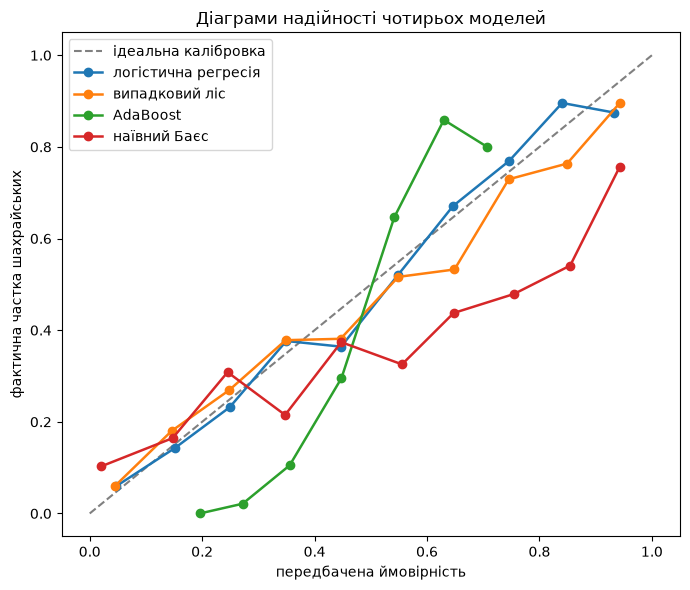

```
AdaBoost тримає всі оцінки в діапазоні 0.196 – 0.711
```

```python
plt.figure(figsize=(7, 6))
plt.plot([0, 1], [0, 1], "--", color="gray", label="ідеальна калібровка")
for name, scores in scores_by_model.items():
    predicted, actual, _ = reliability_by_hand(scores, y_test)
    plt.plot(predicted, actual, marker="o", linewidth=1.8, label=name)
plt.xlabel("передбачена ймовірність")
plt.ylabel("фактична частка шахрайських")
plt.title("Діаграми надійності чотирьох моделей")
plt.legend()
plt.tight_layout()
plt.show()

print("AdaBoost тримає всі оцінки в діапазоні",
      round(scores_by_model["AdaBoost"].min(), 3), "–",
      round(scores_by_model["AdaBoost"].max(), 3))
```

Зверни увагу на AdaBoost: найкраща AUC із чотирьох — і найгірший ECE. Як сортувальниквін найкращий, як вимірювач імовірності — найгірший. Наївний Баєс псує числа інакше:він надто впевнений, бо вважає ціну в гривнях, відносну ціну й відсоток знижки трьоманезалежними доказами й рахує один і той самий доказ тричі.## 9 · Лікування: Платт та ізотонічна регресія`CalibratedClassifierCV` навчає поверх моделі другу, одновимірну: вона бере оцінку йперекладає її в чесну ймовірність. `method='sigmoid'` — це калібрування Платта,`method='isotonic'` — ізотонічна регресія. Параметр `cv=3` потрібен, щоб калібрувальникнавчався не на тих даних, на яких навчена базова модель: у кожній згортці базова модельбачить дві третини, а калібрувальник — відкладену третину.

```python
from sklearn.calibration import CalibratedClassifierCV

def make_model(name):
    """Свіжий, ненавчений екземпляр — CalibratedClassifierCV навчить його сам."""
    if name == "логістична регресія":
        return make_pipeline(StandardScaler(), LogisticRegression(max_iter=1000))
    if name == "AdaBoost":
        return AdaBoostClassifier(n_estimators=100, random_state=42)
    return GaussianNB()

results = []
for name in ["логістична регресія", "AdaBoost", "наївний Баєс"]:
    raw_scores = scores_by_model[name]
    row = {"модель": name,
           "AUC як є": round(roc_auc_score(y_test, raw_scores), 4),
           "Brier як є": round(brier_by_hand(raw_scores, y_test), 4),
           "ECE як є": round(expected_calibration_error(raw_scores, y_test), 4)}
    for method, label in [("sigmoid", "Платт"), ("isotonic", "ізотон.")]:
        calibrated = CalibratedClassifierCV(make_model(name), method=method, cv=3)
        calibrated.fit(X_train, y_train)
        fixed_scores = calibrated.predict_proba(X_test)[:, 1]
        row[f"AUC {label}"] = round(roc_auc_score(y_test, fixed_scores), 4)
        row[f"Brier {label}"] = round(brier_by_hand(fixed_scores, y_test), 4)
        row[f"ECE {label}"] = round(expected_calibration_error(fixed_scores, y_test), 4)
        if name == "AdaBoost":
            scores_by_model[f"AdaBoost · {label}"] = fixed_scores
    results.append(row)

calibration_table = pd.DataFrame(results)
print(calibration_table[["модель", "AUC як є", "AUC Платт", "AUC ізотон."]].to_string(index=False))
print()
print(calibration_table[["модель", "Brier як є", "Brier Платт", "Brier ізотон."]].to_string(index=False))
print()
print(calibration_table[["модель", "ECE як є", "ECE Платт", "ECE ізотон."]].to_string(index=False))
```

```
             модель  AUC як є  AUC Платт  AUC ізотон.
логістична регресія    0.8071     0.8071       0.8072
           AdaBoost    0.8127     0.8158       0.8152
       наївний Баєс    0.7898     0.7899       0.7889

             модель  Brier як є  Brier Платт  Brier ізотон.
логістична регресія      0.1657       0.1657         0.1657
           AdaBoost      0.2012       0.1625         0.1626
       наївний Баєс      0.2042       0.1763         0.1734

             модель  ECE як є  ECE Платт  ECE ізотон.
логістична регресія    0.0271     0.0287       0.0199
           AdaBoost    0.1725     0.0224       0.0277
       наївний Баєс    0.1514     0.0213       0.0213
```

Три речі, які варто прочитати в цих таблицях.1. **AUC майже не змінилась.** Калібрування — монотонне перетворення, воно не може переставити оголошення місцями. Здатність розрізняти воно не покращує й не псує.2. **Brier і ECE впали там, де було зламано.** У AdaBoost — різко.3. **У логістичної регресії не змінилось нічого.** Калібрувати калібровану модель — марна робота. Спершу міряй, потім лікуй.Подивимось на AdaBoost до й після.

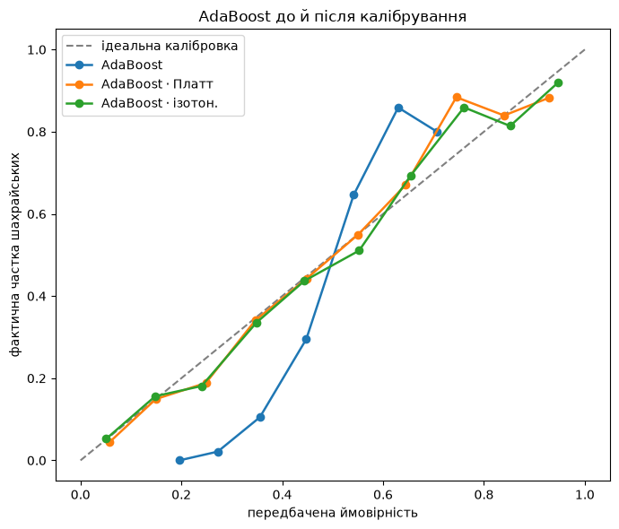

```
діапазон оцінок до калібрування:  0.196 – 0.711
після калібрування Платта:        0.008 – 0.964
```

```python
plt.figure(figsize=(7, 6))
plt.plot([0, 1], [0, 1], "--", color="gray", label="ідеальна калібровка")
for name in ["AdaBoost", "AdaBoost · Платт", "AdaBoost · ізотон."]:
    predicted, actual, _ = reliability_by_hand(scores_by_model[name], y_test)
    plt.plot(predicted, actual, marker="o", linewidth=1.8, label=name)
plt.xlabel("передбачена ймовірність")
plt.ylabel("фактична частка шахрайських")
plt.title("AdaBoost до й після калібрування")
plt.legend()
plt.tight_layout()
plt.show()

before = scores_by_model["AdaBoost"]
after = scores_by_model["AdaBoost · Платт"]
print("діапазон оцінок до калібрування: ", round(before.min(), 3), "–", round(before.max(), 3))
print("після калібрування Платта:       ", round(after.min(), 3), "–", round(after.max(), 3))
```

```python
raw_boost = scores_by_model["AdaBoost"]
fixed_boost = scores_by_model["AdaBoost · Платт"]

print("сирий AdaBoost на порозі 0.1: заблоковано",
      int((raw_boost >= formula_threshold).sum()), "оголошень із", len(y_test),
      "→", losses_at(raw_boost, y_test, formula_threshold), "грн")
print("він же після калібрування:    заблоковано",
      int((fixed_boost >= formula_threshold).sum()), "оголошень із", len(y_test),
      "→", losses_at(fixed_boost, y_test, formula_threshold), "грн")

# а якщо поріг не рахувати формулою, а підбирати по даних — обидві версії однакові
raw_best = min(losses_at(raw_boost, y_test, t) for t in thresholds)
fixed_best = min(losses_at(fixed_boost, y_test, t) for t in thresholds)
print()
print("найкращі можливі втрати, сирий:      ", raw_best, "грн")
print("найкращі можливі втрати, калібрований:", fixed_best, "грн")
print("порядок той самий, тому й мінімум майже той самий —",
      "калібрування потрібне саме тоді, коли поріг РАХУЮТЬ, а не підбирають")
```

```
сирий AdaBoost на порозі 0.1: заблоковано 2100 оголошень із 2100 → 274400 грн
він же після калібрування:    заблоковано 1767 оголошень із 2100 → 237800 грн

найкращі можливі втрати, сирий:       235200 грн
найкращі можливі втрати, калібрований: 231000 грн
порядок той самий, тому й мінімум майже той самий — калібрування потрібне саме тоді, коли поріг РАХУЮТЬ, а не підбирають
```